# Name: Tanner Woods

## Imports

```python
import pandas as pd
import numpy as np
import matplotlib.pyplot as plt
import datetime
from dateutil.relativedelta import relativedelta
```

# Question 1

## Question 1A

```python
HW_data = pd.read_csv('hw2_data.csv', parse_dates = True, index_col = 0)
Strategy = pd.DataFrame()

def scale(x):
    return (x-x.min())/(x.max()-x.min())

Strategy['Inf_Diff'] = scale(HW_data['Inf_EU'] - HW_data['Inf_US'])
Strategy.head()
```

|  | Inf_Diff |
| --- | --- |
| 2003-12-01 | 0.580951 |
| 2004-01-01 | 0.537133 |
| 2004-02-01 | 0.509294 |
| 2004-03-01 | 0.535795 |
| 2004-04-01 | 0.535871 |

## Question 1B

```python
## Fitting Kalman filter
k = 0.5
w = 10
z = 1.96
Strategy["Filter"] = Strategy.Inf_Diff.ewm(alpha = k, adjust = False).mean()
Strategy["Filter Error"] = Strategy.Inf_Diff - Strategy["Filter"]
Strategy.head()
```

|  | Inf_Diff | Filter | Filter Error |
| --- | --- | --- | --- |
| 2003-12-01 | 0.580951 | 0.580951 | 0.000000 |
| 2004-01-01 | 0.537133 | 0.559042 | -0.021909 |
| 2004-02-01 | 0.509294 | 0.534168 | -0.024874 |
| 2004-03-01 | 0.535795 | 0.534981 | 0.000813 |
| 2004-04-01 | 0.535871 | 0.535426 | 0.000445 |

## Question 1C

```python
Strategy["Std Dev"] = Strategy["Filter Error"].rolling(w).std()
Strategy["Upper"] = Strategy["Filter"] + z*Strategy["Std Dev"]
Strategy["Lower"] = Strategy["Filter"] - z*Strategy["Std Dev"]
Strategy["test"] = np.where(Strategy["Filter Error"].abs()>z*Strategy["Std Dev"], -1, 0)*np.sign(Strategy["Filter Error"])
Strategy = Strategy.dropna()
Strategy.head()
```

|  | Inf_Diff | Filter | Filter Error | Std Dev | Upper | Lower | test |
| --- | --- | --- | --- | --- | --- | --- | --- |
| 2004-09-01 | 0.515047 | 0.483778 | 0.031269 | 0.019568 | 0.522131 | 0.445425 | 0.0 |
| 2004-10-01 | 0.478392 | 0.481085 | -0.002693 | 0.019437 | 0.519182 | 0.442988 | -0.0 |
| 2004-11-01 | 0.414160 | 0.447622 | -0.033463 | 0.020537 | 0.487875 | 0.407370 | -0.0 |
| 2004-12-01 | 0.329158 | 0.388390 | -0.059232 | 0.025390 | 0.438155 | 0.338625 | 1.0 |
| 2005-01-01 | 0.385294 | 0.386842 | -0.001548 | 0.025242 | 0.436316 | 0.337368 | -0.0 |

# Question 2

## Question 2A

```python
Strategy['Long/Short'] = np.where(Strategy['Inf_Diff'] > Strategy['Filter'].shift(), 1,-1)
Strategy['Returns'] = Strategy['Inf_Diff'] / Strategy['Inf_Diff'].shift()
Strategy['Log Returns'] = np.log(Strategy['Inf_Diff'] / Strategy['Inf_Diff'].shift())
Strategy['Strategy Returns'] = Strategy['Long/Short'].shift() * Strategy['Log Returns']
Strategy['Cumulative Returns'] = (np.exp(Strategy['Strategy Returns'].cumsum())-1)*100
Strategy.head()
```

|  | Inf_Diff | Filter | Filter Error | Std Dev | Upper | Lower | test | Long/Short | Returns | Log Returns | Strategy Returns | Cumulative Returns |
| --- | --- | --- | --- | --- | --- | --- | --- | --- | --- | --- | --- | --- |
| 2004-09-01 | 0.515047 | 0.483778 | 0.031269 | 0.019568 | 0.522131 | 0.445425 | 0.0 | -1 | NaN | NaN | NaN | NaN |
| 2004-10-01 | 0.478392 | 0.481085 | -0.002693 | 0.019437 | 0.519182 | 0.442988 | -0.0 | -1 | 0.928832 | -0.073828 | 0.073828 | 7.662111 |
| 2004-11-01 | 0.414160 | 0.447622 | -0.033463 | 0.020537 | 0.487875 | 0.407370 | -0.0 | -1 | 0.865733 | -0.144179 | 0.144179 | 24.359557 |
| 2004-12-01 | 0.329158 | 0.388390 | -0.059232 | 0.025390 | 0.438155 | 0.338625 | 1.0 | -1 | 0.794762 | -0.229712 | 0.229712 | 56.473941 |
| 2005-01-01 | 0.385294 | 0.386842 | -0.001548 | 0.025242 | 0.436316 | 0.337368 | -0.0 | -1 | 1.170542 | 0.157467 | -0.157467 | 33.676453 |

## Question 2B

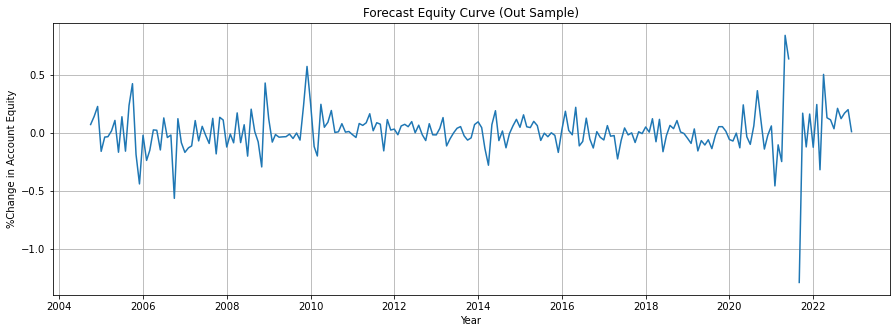

```python
plt.figure(figsize = (15, 5))
plt.title("Forecast Equity Curve (Out Sample)")
plt.plot(Strategy['Strategy Returns'])
plt.ylabel('%Change in Account Equity')
plt.xlabel('Year')
plt.grid()
plt.show()
```

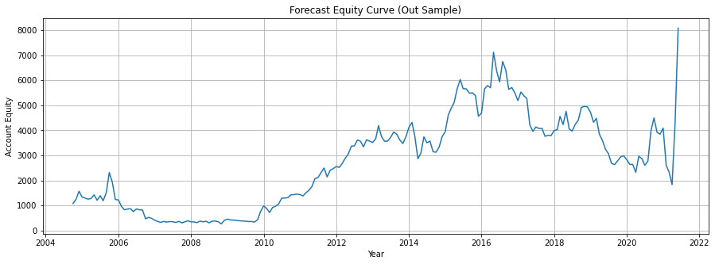

```python
plt.figure(figsize = (15, 5))
plt.title("Forecast Equity Curve (Out Sample)")
plt.plot((((Strategy["Cumulative Returns"]/100)+1)*1000))
plt.ylabel('Account Equity')
plt.xlabel('Year')
plt.grid()
plt.show()
```

## Question 2C

```python
## Getting non-zero signals
df = Strategy[Strategy.test != 0][['Long/Short','Inf_Diff']].copy()
df = df.iloc[0:26,:]
df['D'] = df["Long/Short"]

## Get the realized interest diff
df['s_current'] = Strategy[Strategy.index.isin(df.index)]["Inf_Diff"].values
month_shift = [df.index[i]+relativedelta(months=+1) for i in range(0,len(df))][0:27]
df['s_future'] = Strategy[Strategy.index.isin(month_shift)]["Inf_Diff"].values
df['R'] = np.where(df['s_future'] >= df['s_current'], 1, -1)

## Sample covariance
df['W'] = (df['D']-np.mean(df['D']))*(df['R']-np.mean(df['R']))
T_B = np.mean(df['W'])

## Newey-West LRV estimator
dy = df['W'] - np.mean(df['W'])
gamma_0 = sum((dy)**2)/len(df)
gamma_1 = np.mean((dy*dy.shift(-1))[:len(df)-1])
LRV = gamma_0 + 2*(1-1/2)*gamma_1
```

```python
from scipy.stats import norm

statistic = T_B/np.sqrt(LRV/df.shape[0])
print('Test statistic : ', statistic, ', 5 % critical value : ', round(norm.ppf(0.95),2))
```

```
Test statistic :  0.7508307050293813 , 5 % critical value :  1.64
```

We fail in rejecting $H_0: Cov(D_{t,t+h},R_{t,t+h}) = 0$ in favor of $H_1: Cov(D_{t,t+h},R_{t,t+h}) > 0$. This implies that our directional forecasts did not capture the realized change in interest rate differential.

```python
df['W_2'] = df['D']*(df['s_future']-df['s_current'])
T_WB = np.mean(df['W_2'])

dy_2 = df['W_2'] - np.mean(df['W_2'])
gamma_0 = sum((dy_2)**2)/len(df)
gamma_1 = np.mean((dy_2*dy_2.shift(-1))[:len(df)-1])
LRV_2 = gamma_0 + 2*(1-1/2)*gamma_1

statistic_2 = T_WB/np.sqrt(LRV_2/len(df))
print('Test statistic : ', statistic_2, ', 5 % critical value : ', round(norm.ppf(0.95),2))
```

```
Test statistic :  1.5508214312774453 , 5 % critical value :  1.64
```

We fail in rejecting $H_0: E(D_{t,t+h}(s_{t+H}-s_t)) = 0$ in favor of $H_1: E(D_{t,t+h}(s_{t+H}-s_t)) > 0)$. This implies that our directional forecasts did not capture the realized change in interest rate differential.

## Question 2D

```python
def AutoTradingStrat(k,w,z):
    k = k
    w = w
    z = z

    print(f'Hyperparameters: (k = {k}, w = {w}, z = {z})')
    Strategy = pd.DataFrame()
    Strategy['Inf_Diff'] = scale(HW_data['Inf_EU'] - HW_data['Inf_US'])
    Strategy["Filter"] = Strategy.Inf_Diff.ewm(alpha = k, adjust = False).mean()
    Strategy["Filter Error"] = Strategy.Inf_Diff - Strategy["Filter"]
    Strategy["Std Dev"] = Strategy["Filter Error"].rolling(w).std()
    Strategy["Upper"] = Strategy["Filter"] + z*Strategy["Std Dev"]
    Strategy["Lower"] = Strategy["Filter"] - z*Strategy["Std Dev"]
    Strategy["test"] = np.where(Strategy["Filter Error"].abs()>z*Strategy["Std Dev"], -1, 0)*np.sign(Strategy["Filter Error"])
    Strategy['Long/Short'] = np.where(Strategy['Inf_Diff'] > Strategy['Filter'].shift(), 1,-1)
    Strategy = Strategy.dropna()

    ## Getting non-zero signals
    df = Strategy[Strategy.test != 0][['Long/Short','Inf_Diff']].copy()
    df = df.iloc[0:26,:]
    df['D'] = df["Long/Short"]

    ## Get the realized interest diff
    df['s_current'] = Strategy[Strategy.index.isin(df.index)]["Inf_Diff"].values
    month_shift = [df.index[i]+relativedelta(months=+1) for i in range(0,len(df))][0:27]
    df['s_future'] = Strategy[Strategy.index.isin(month_shift)]["Inf_Diff"].values
    df['R'] = np.where(df['s_future'] >= df['s_current'], 1, -1)

    ## Sample covariance
    df['W'] = (df['D']-np.mean(df['D']))*(df['R']-np.mean(df['R']))
    T_B = np.mean(df['W'])

    ## Newey-West LRV estimator
    dy = df['W'] - np.mean(df['W'])
    gamma_0 = sum((dy)**2)/len(df)
    gamma_1 = np.mean((dy*dy.shift(-1))[:len(df)-1])
    LRV = gamma_0 + 2*(1-1/2)*gamma_1

    from scipy.stats import norm

    statistic = T_B/np.sqrt(LRV/df.shape[0])
    print('  Binomial test statistic : ', statistic, ', 5 % critical value : ', round(norm.ppf(0.95),2))

    if statistic <= round(norm.ppf(0.95),2):
        print('  Fail in rejecting binomial test null in favor of alternative')

    if statistic > round(norm.ppf(0.95),2):
        print('  Succeed in rejecting binomial test null in favor of alternative')

    print('\n')

    df['W_2'] = df['D']*(df['s_future']-df['s_current'])
    T_WB = np.mean(df['W_2'])

    dy_2 = df['W_2'] - np.mean(df['W_2'])
    gamma_0 = sum((dy_2)**2)/len(df)
    gamma_1 = np.mean((dy_2*dy_2.shift(-1))[:len(df)-1])
    LRV_2 = gamma_0 + 2*(1-1/2)*gamma_1

    statistic_2 = T_WB/np.sqrt(LRV_2/len(df))
    print('  Weighted binomial test statistic : ', statistic_2, ', 5 % critical value : ', round(norm.ppf(0.95),2))

    if statistic_2 <= round(norm.ppf(0.95),2):
        print('  Fail in rejecting binomial test null in favor of alternative')

    if statistic_2 > round(norm.ppf(0.95),2):
        print('  Succeed in rejecting binomial test null in favor of alternative')

    print('\n')
```

```python
k_list = [0.66, 0.99]
w_list = [5, 15]
z_list = [1.65, 2.807]

AutoTradingStrat(0.33, 5, 1.65)
AutoTradingStrat(0.33, 15, 2.807)

AutoTradingStrat(0.66, 5, 1.65)
AutoTradingStrat(0.66, 15, 2.807)
```

```
Hyperparameters: (k = 0.33, w = 5, z = 1.65)
  Binomial test statistic :  1.3554746614337523 , 5 % critical value :  1.64
  Fail in rejecting binomial test null in favor of alternative


  Weighted binomial test statistic :  1.0322596914510769 , 5 % critical value :  1.64
  Fail in rejecting binomial test null in favor of alternative


Hyperparameters: (k = 0.33, w = 15, z = 2.807)
  Binomial test statistic :  2.449489742783178 , 5 % critical value :  1.64
  Succeed in rejecting binomial test null in favor of alternative


  Weighted binomial test statistic :  1.2934505663668427 , 5 % critical value :  1.64
  Fail in rejecting binomial test null in favor of alternative


Hyperparameters: (k = 0.66, w = 5, z = 1.65)
  Binomial test statistic :  3.124700059433686 , 5 % critical value :  1.64
  Succeed in rejecting binomial test null in favor of alternative


  Weighted binomial test statistic :  2.0114043010623677 , 5 % critical value :  1.64
  Succeed in rejecting binomial test null in favor of alternative


Hyperparameters: (k = 0.66, w = 15, z = 2.807)
  Binomial test statistic :  nan , 5 % critical value :  1.64


  Weighted binomial test statistic :  inf , 5 % critical value :  1.64
  Succeed in rejecting binomial test null in favor of alternative
```

# Question 3

## Question 3B

# Question 4

## Question 4C

# Question 5

## Question 5A

Adjustments made by the Federal Reserve:

1. Reserve balance interest rate up from 0.15% to 4.65%
2. Federal funds rate range adjusted from 0 - 0.25% to 4.5 - 4.75%
3. Overnight repurchase agreements minimum bid rate up from 0.25% to 4.75%
4. Overnight reverse repurchase agreements minimum bid rate up from 0.05% to 4.55%
5. Rollover auction threshold of 60 million USD instituted for principal payments from Treasury securities
6. Reinvestment threshold of 35 million USD instituted for principal payments from agency debt and MBS

Adjustments made by the European Central Bank:

1. Declared expected basis point value of next increase to key interest rate
2. Shifting ECB corporate bond purchases to focus on climate-progressive companies

## Question 5B

Banks have substantially cut lending to businesses, while households have also experienced decreases in borrowing. Furthermore, inflation continues to fall within a range higher relative to the US.

## Question 5C

Drops in borrowing/lending implies a contractionary economy with lower levels of economic activity. Despite a greater relative incentive to hold assets in Euros due to the higher interest rate, an ailing economy in the Eurozone relative to the US encourages holdings in USD. Furthermore, while both the Euro and USD are struggling with inflationary pressures, lower levels of inflation for USD also encourages holdings in it over the Euro.

## Question 6

Possible disinflationary actions I did not see discussed (in the article or prior FOMC statements) are:

1. Communicating support for increasing tax rates and/or instituting new forms of taxation on the wealthy
2. Increasing bank reserve requirements

Suggestion 1 could improve the possibility of wealth transfer from the upper classes into the much larger middle and lower classes. It could also increase economic activity as the propensity to spend a larger proportion of income increases as an individual’s overall wealth decreases; e.g. A poor individual given $20 is more likely to immediately spend it relative to a wealthy individual.

Suggestion 2 is a general disinflationary measure to reduce the amount of active money within the economy. However, the knock-on effect of lowered economic activity could nullify or overcome the disinflationary effect.